# CP&FP_02_beta_diversity - RI and Batch 1 FP removed - Unplanted CTRL removed

Kris de Kreek

2026-03-19

# 2.0 - Basic beta diversity analysis

This script should be run after script “01_loading_and_pre_processing.rmd” because it generates all the global environment objects and also loads the libraries

On this script we will evaluate beta diversity - the differences in the microbial community compositions across samples. We will make ordination plots and multivariate tests

This script is originally made by Pedro Beschoren da Costa for the MeJA_Pilot and modified to fit my data.

### Load libraries

```r
library(purrr)
packageVersion("purrr")
```

```
## [1] '1.1.0'
```

```r
library(phyloseq)
packageVersion("phyloseq")
```

```
## [1] '1.52.0'
```

```r
library(ggplot2)
packageVersion("ggplot2")
```

```
## [1] '4.0.0'
```

```r
library(vegan)
packageVersion("vegan")
```

```
## [1] '2.7.2'
```

```r
library(tibble) #needed for function rownames_to_columns
packageVersion("tibble")
```

```
## [1] '3.3.0'
```

```r
library(factoextra) #for heatmap function fviz_dist
packageVersion("factoextra")
```

```
## [1] '1.0.7'
```

```r
library(patchwork) # for wrap_plot
packageVersion("patchwork")
```

```
## [1] '1.3.2'
```

```r
library(cowplot) # For extracting legend
packageVersion("cowplot")
```

```
## [1] '1.2.0'
```

# 2.1 - Beta Diversity plots

Beta diversity plots are the beating heart or microbiome analysis. Here you will be able to visually tell if communities differ according to treatment or not. It can be a very long topic but here I only use one option.

## 2.1.1 - Loading data

```r
load("C:/Users/kreek001/OneDrive - Wageningen University & Research/Chapters/Experimental Chapter 3/RScripts/GitHub/TwelveAccessionExperiment/MicrobiomeAnalysis/Data/Phyloseq_objects/CP_FP_together/CSS_bac_ps.RData")
```

### Remove outliers

Outliers with low library size (check per accession) are removed here.  
Samples with low library size (lowest 10% in t-distr.) of that accession: C085 (5%), C256 (4%), C326 (0.7%), C375 (7%), C379 (9%), C429 (1%)  
Not low: C105 (56%), C217 (51%), C425 (34%), C438 (36%), C480 (21%)  
Not removed: C110 (51%), C380 (22%)

C478, C043, F178 and F371 were removed earlier during ps formation based on rarification curve.

```r
Outliers <- c("C085", "C256", "C326", "C375", "C379", "C429")
samples_to_keep <- setdiff(sample_names(CSS_bac_ps), Outliers) # only keep samples that are not in both objects
CSS_bac_ps <- prune_samples(samples_to_keep, CSS_bac_ps) #only keep samples that are in samples_to_keep
```

```r
CSS_bac_ps <- subset_samples(CSS_bac_ps, Batch != 1 | Phase_PSF != "FP")
table(CSS_bac_ps@sam_data$Phase_PSF, CSS_bac_ps@sam_data$Batch)
```

```
##
##        1   2
##   CP 142 143
##   FP   0  64
```

```r
CSS_bac_ps <- subset_samples(CSS_bac_ps, Accession != "RI" | Phase_PSF != "FP")
table(CSS_bac_ps@sam_data$Phase_PSF, CSS_bac_ps@sam_data$Accession)
```

```
##
##      OH DD HE KI VL CD RI KT MC HM IT1 GO1 Un
##   CP 23 22 23 22 23 23 22 24 23 24  24  22 10
##   FP  0  0  0  0 11 12  0  0  0 11   0  12  0
```

```r
CSS_bac_ps <- subset_samples(CSS_bac_ps, Accession != "Un")
table(CSS_bac_ps@sam_data$Phase_PSF, CSS_bac_ps@sam_data$Accession)
```

```
##
##      OH DD HE KI VL CD RI KT MC HM IT1 GO1
##   CP 23 22 23 22 23 23 22 24 23 24  24  22
##   FP  0  0  0  0 11 12  0  0  0 11   0  12
```

## 2.3.3 PCoA plot

Here, the first two axis that explain most of the variance are plotted. This data may not fully reflect the values you see in the distance matrix because that takes into account all axis. In contrast, the NMDS plot tries by iterations to reflect better the distances of the distance matrix by iterations using a value stress.

### Preparing PCoA plots

```r
# Calculate Bray-Curtis distance matrix
bray_dist <- phyloseq::distance(CSS_bac_ps, method = "bray")

# Run classical MDS with cmdscale()
mds_result <- cmdscale(bray_dist, k = 2, eig = TRUE)

# Extract coordinates
mds_coords <- as.data.frame(mds_result$points)
colnames(mds_coords) <- c("MDS1", "MDS2")

# Add sample IDs as a column
mds_coords$SampleID <- rownames(mds_coords)

# Extract sample metadata
metadata_df <- data.frame(sample_data(CSS_bac_ps))
metadata_df$SampleID <- rownames(metadata_df)

# Merge ordination coordinates with metadata
plot_df <- merge(mds_coords, metadata_df, by = "SampleID")

# Eigenvalues percentage explained variance
perc_expl1 <- 100 * (mds_result$eig / sum(mds_result$eig))
perc_expl1[1:4] # percentage explained first four axes
```

```
## [1] 14.807634  1.858216  1.480179  1.129839
```

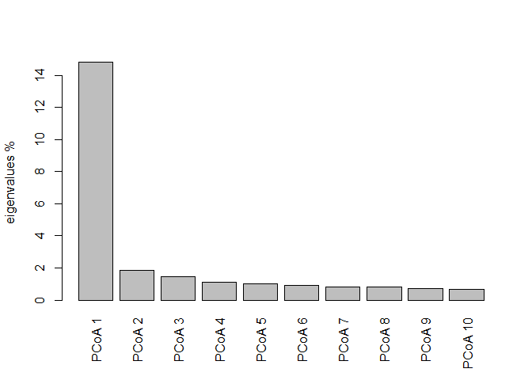

```r
barplot(perc_expl1[1:10], names = paste ('PCoA', 1:10), las = 3, ylab = 'eigenvalues %')
```

### Ordination plots

#### Accession

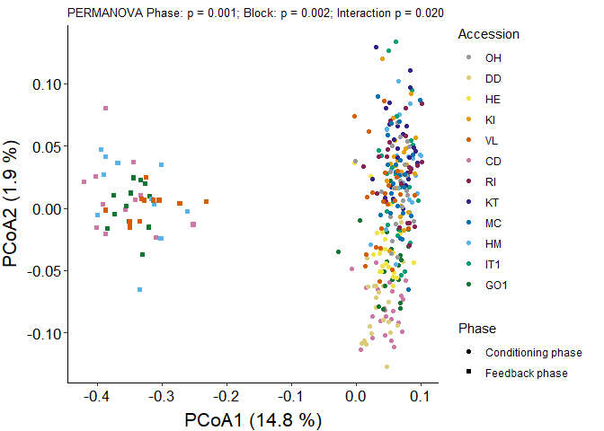

```r
colors12 <- c("#999999", "#DDCC77", "#F0E442", "#E69F00", "#D55E00", "#CC79A7",
              "#882255", "#332288", "#0072B2", "#56B4E9",  "#009E73", "#117733") # "#000000", "#44AA99", "#AA4499",

ggplot(plot_df, aes(x = MDS1, y = MDS2, color = Accession, shape = Phase_PSF)) +
  geom_point(size = 1.5, alpha = 1) +
  scale_color_manual(values = colors12) +
  xlab(paste0("PCoA1 (", round(perc_expl1[1], 1), " %)")) +
  ylab(paste0("PCoA2 (", round(perc_expl1[2], 1), " %)")) +
  scale_shape_manual(name = "Phase",
                     values = c(CP = 16, FP = 15),
                     labels = c(CP = "Conditioning phase", FP = "Feedback phase")) +
  ggtitle("PERMANOVA Phase: p = 0.001; Block: p = 0.002; Interaction p = 0.020") +
  theme(panel.background = element_rect(fill = "white"), #theme of the graph
        panel.border = element_blank(),
        axis.line = element_line(), #show line for x and y axis
        plot.title = element_text(size = 10, hjust = 0),
        axis.text = element_text(size = 13, color = "black"),
        axis.title = element_text(size = 16),
        axis.title.x = element_text(vjust = -0.5),
        axis.title.y = element_text(vjust = 2.5), #, hjust = -0
        strip.text = element_text(size = 13),
        plot.margin = margin(5.5, 12, 5.5, 5.5, "points"),
        legend.position = "right")
```

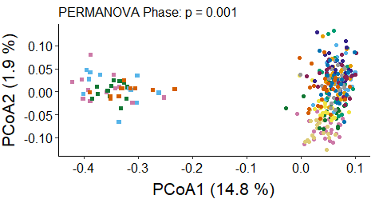

```r
q <- ggplot(plot_df, aes(x = MDS1, y = MDS2, color = Accession, shape = Phase_PSF)) +
  geom_point(size = 1.5, alpha = 1) +
  scale_color_manual(values = colors12) +
  xlab(paste0("PCoA1 (", round(perc_expl1[1], 1), " %)")) +
  ylab(paste0("PCoA2 (", round(perc_expl1[2], 1), " %)")) +
  scale_shape_manual(name = "Phase",
                     values = c(CP = 16, FP = 15),
                     labels = c(CP = "Conditioning phase", FP = "Feedback phase")) +
  ggtitle("PERMANOVA Phase: p = 0.001") +
  guides(color = guide_legend(ncol = 2),   # <- two columns
         shape = guide_legend(ncol = 1)) +
  theme(panel.background = element_rect(fill = "white"), #theme of the graph
        panel.border = element_blank(),
        axis.line = element_line(), #show line for x and y axis
        plot.title = element_text(size = 12, hjust = 0),
        axis.text = element_text(size = 12, color = "black"),
        axis.title = element_text(size = 16),
        axis.title.x = element_text(vjust = -0.5),
        axis.title.y = element_text(vjust = 2.5), #, hjust = -0
        legend.title = element_text(size = 14),
        legend.text = element_text(size = 12),
        #strip.text = element_text(size = 13),
        plot.margin = margin(5.5, 12, 5.5, 5.5, "points"),
        legend.position = "none")

print(q)
```

```r
mapply(function(x)
  ggsave(plot = last_plot(),
         filename = x,
         path = "C:/Users/kreek001/OneDrive - Wageningen University & Research/Chapters/Experimental Chapter 3/Result/Final graphs",
         scale = 2.2,
         width = 4,
         height = 3.9,
         units = "cm",
         dpi = 300),
  x = c("CP_FP_BetaDiv_Acc_Phase.svg", "CP_FP_BetaDiv_Acc_Phase.png"))
```

```
##                                                                                                                     CP_FP_BetaDiv_Acc_Phase.svg
## "C:/Users/kreek001/OneDrive - Wageningen University & Research/Chapters/Experimental Chapter 3/Result/Final graphs/CP_FP_BetaDiv_Acc_Phase.svg"
##                                                                                                                     CP_FP_BetaDiv_Acc_Phase.png
## "C:/Users/kreek001/OneDrive - Wageningen University & Research/Chapters/Experimental Chapter 3/Result/Final graphs/CP_FP_BetaDiv_Acc_Phase.png"
```

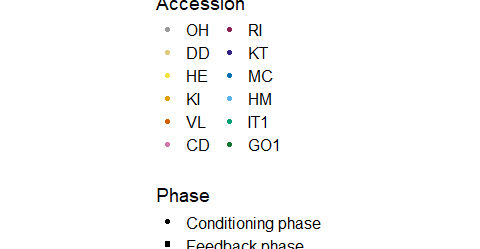

```r
# Legend
legend_acc <- get_legend(q + theme(legend.position = "right"))
ggdraw(legend_acc)
```

```r
mapply(function(x)
  ggsave(plot = last_plot(),
         filename = x,
         path = "C:/Users/kreek001/OneDrive - Wageningen University & Research/Chapters/Experimental Chapter 3/Result/Final graphs",
         scale = 2.2,
         width = 1.8,
         height = 3.1,
         units = "cm",
         dpi = 300),
  x = c("CP_FP_BetaDiv_Acc_Phase_legend.svg", "CP_FP_BetaDiv_Acc_Phase_legend.png"))
```

```
##                                                                                                                     CP_FP_BetaDiv_Acc_Phase_legend.svg
## "C:/Users/kreek001/OneDrive - Wageningen University & Research/Chapters/Experimental Chapter 3/Result/Final graphs/CP_FP_BetaDiv_Acc_Phase_legend.svg"
##                                                                                                                     CP_FP_BetaDiv_Acc_Phase_legend.png
## "C:/Users/kreek001/OneDrive - Wageningen University & Research/Chapters/Experimental Chapter 3/Result/Final graphs/CP_FP_BetaDiv_Acc_Phase_legend.png"
```

#### Caterpillar treatment

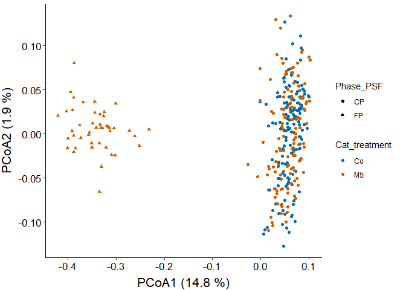

```r
ggplot(plot_df, aes(x = MDS1, y = MDS2, color = Cat_treatment, shape = Phase_PSF)) +
  geom_point(size = 1.5, alpha = 1) +
  scale_color_manual(values = c("#0072B2", "#D55E00", "black")) +
  xlab(paste0("PCoA1 (", round(perc_expl1[1], 1), " %)")) +
  ylab(paste0("PCoA2 (", round(perc_expl1[2], 1), " %)")) +
  #ggtitle("PERMANOVA Accession: p = 0.001") +
  theme(panel.background = element_rect(fill = "white"), #theme of the graph
        panel.border = element_blank(),
        axis.line = element_line(), #show line for x and y axis
        plot.title = element_text(size = 10, hjust = 0),
        axis.text = element_text(size = 13, color = "black"),
        axis.title = element_text(size = 16),
        axis.title.x = element_text(vjust = -0.5),
        axis.title.y = element_text(vjust = 2.5), #, hjust = -0
        strip.text = element_text(size = 13),
        plot.margin = margin(5.5, 12, 5.5, 5.5, "points"),
        legend.position = "right")
```

#### Soil conditioning

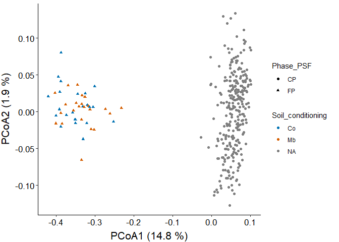

```r
ggplot(plot_df, aes(x = MDS1, y = MDS2, color = Soil_conditioning, shape = Phase_PSF)) +
  geom_point(size = 1.5, alpha = 1) +
  scale_color_manual(values = c("#0072B2", "#D55E00", "red")) +
  xlab(paste0("PCoA1 (", round(perc_expl1[1], 1), " %)")) +
  ylab(paste0("PCoA2 (", round(perc_expl1[2], 1), " %)")) +
  #ggtitle("PERMANOVA Accession: p = 0.001") +
  theme(panel.background = element_rect(fill = "white"), #theme of the graph
        panel.border = element_blank(),
        axis.line = element_line(), #show line for x and y axis
        plot.title = element_text(size = 10, hjust = 0),
        axis.text = element_text(size = 13, color = "black"),
        axis.title = element_text(size = 16),
        axis.title.x = element_text(vjust = -0.5),
        axis.title.y = element_text(vjust = 2.5), #, hjust = -0
        strip.text = element_text(size = 13),
        plot.margin = margin(5.5, 12, 5.5, 5.5, "points"),
        legend.position = "right")
```

#### Domestication

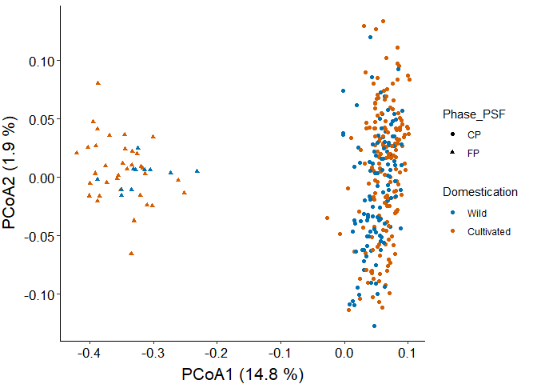

```r
ggplot(plot_df, aes(x = MDS1, y = MDS2, color = Domestication, shape = Phase_PSF)) +
  geom_point(size = 1.5, alpha = 1) +
  scale_color_manual(values = c("#0072B2", "#D55E00", "black")) +
  xlab(paste0("PCoA1 (", round(perc_expl1[1], 1), " %)")) +
  ylab(paste0("PCoA2 (", round(perc_expl1[2], 1), " %)")) +
  #ggtitle("PERMANOVA Domestication: p = 0.001") +
  theme(panel.background = element_rect(fill = "white"), #theme of the graph
        panel.border = element_blank(),
        axis.line = element_line(), #show line for x and y axis
        plot.title = element_text(size = 10, hjust = 0),
        axis.text = element_text(size = 13, color = "black"),
        axis.title = element_text(size = 16),
        axis.title.x = element_text(vjust = -0.5),
        axis.title.y = element_text(vjust = 2.5), #, hjust = -0
        strip.text = element_text(size = 13),
        plot.margin = margin(5.5, 12, 5.5, 5.5, "points"),
        legend.position = "right")
```

#### Labeling outliers

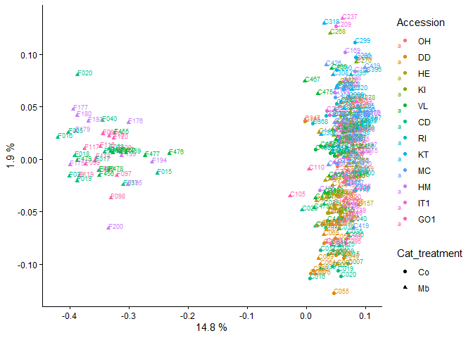

```r
ggplot(plot_df, aes(x = MDS1, y = MDS2, color = Accession, shape = Cat_treatment)) +
  geom_point(size = 1.5, alpha = 1) +
  geom_text(label = plot_df$SampleID, hjust = 0, vjust = 0, size = 2.5) +
  xlab(paste(round(perc_expl1[1], 1), "%")) +
  ylab(paste(round(perc_expl1[2], 1), "%")) +
  theme_classic() +
  theme(plot.title = element_text(size = 10, face = "bold", hjust = 0.5),
        legend.position = "right")
```

```r
rm(bray_dist, mds_result, mds_coords, metadata_df, plot_df)
```

# 2.4 - P values for beta diversity

A permutation anova will tell if the differences in the microbial community structure are significant or not. They will essentially help you separate the data clouds of your ordination with confidence levels. It will compare centroids and spread of the different groups. It is based on the distance matrix and does not assume normality of the data (non-parametric). Be careful when beta dispersion is different for different groups. It may give misleading low p-values when centroids are apart. [More info](https://archetypalecology.wordpress.com/2018/02/21/permutational-multivariate-analysis-of-variance-permanova-in-r-preliminary/).

## 2.4.1 - Run PERMANOVA at ASV level

You will need to run, test and check several different models and data slices to have final insight into the data set you are evaluating. get used with testing multiple models!

```r
# Running the permanova with vegan::adonis2() on a single phyloseq object is very simple
metadata_Bac <- as(sample_data(CSS_bac_ps),"data.frame")

set.seed(5235)
dist <- phyloseq::distance(t(otu_table(CSS_bac_ps)), method = "bray")

set.seed(5235)
Permanova_CP_FP <- adonis2(dist ~ Phase_PSF, data = metadata_Bac, method = "bray", by = "terms", permutations = 999)
Permanova_CP_FP
```

```
## Permutation test for adonis under reduced model
## Terms added sequentially (first to last)
## Permutation: free
## Number of permutations: 999
##
## adonis2(formula = dist ~ Phase_PSF, data = metadata_Bac, permutations = 999, method = "bray", by = "terms")
##            Df SumOfSqs     R2      F Pr(>F)
## Phase_PSF   1    6.335 0.1434 53.403  0.001 ***
## Residual  319   37.839 0.8566
## Total     320   44.173 1.0000
## ---
## Signif. codes:  0 '***' 0.001 '**' 0.01 '*' 0.05 '.' 0.1 ' ' 1
```

```r
Permanova_CP_FP <- as.data.frame(Permanova_CP_FP)[1, ]
write.csv(Permanova_CP_FP, "C:/Users/kreek001/OneDrive - Wageningen University & Research/Chapters/Experimental Chapter 3/RScripts/GitHub/TwelveAccessionExperiment/MicrobiomeAnalysis/Data/Statistical_output/CP_FP/Permanova_CP_FP.csv")
```